# Basics of working with phylogenies

Author

Jeet Sukumaran

## 1 Creating and converting phylogenetic data files

### 1.1 NEXUS tree file

- Create a NEWICK tree file (e.g., “sample2.tre”) with the following tree:

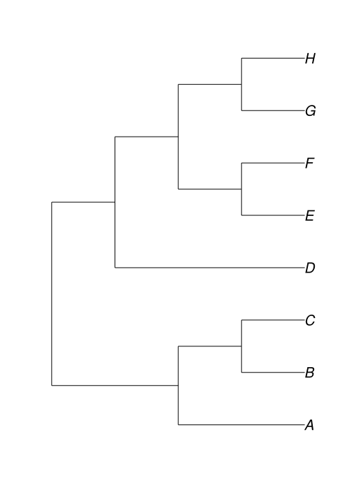

- Visualize it in FigTree to check your work.
- Create a copy of this file with a “.nex” extension, and convert the data to NEXUS format.
- Again, check to make sure it is OK by visualizing it in FigTree to check your work.

### 1.2 From FASTA to NEXUS

- Open the data file, “cetaceans.fasta”, in a text editor and have a look at it.
- Copy the file to “cetaceans.nex”.
- Open the file, “cetaceans.nex” in a text editor and convert it to NEXUS format.
- Check to see if the file has been created correctly by opening it up in PAUP*:

  ```
  $ paup
  paup> exe cetaceans.nex
  ```

## 2 Converting between data formats using a script

### 2.1 Installing DendroPy

- Ensure that you have conda running:

  ```
  $ conda --version
  ```

- Install the development version of DendroPy:

  ```
  $ python -m pip install \
      git+https://github.com/jeetsukumaran/DendroPy.git@development-master
  ```

  or, if this does not work:

  ```
  $ python -m pip install \
      git+git://github.com/jeetsukumaran/DendroPy.git@development-master
  ```

- Check to see if you have everything installed:

  ```
  $ dendropy-format --help
  ```

### 2.2 Converting from NEXUS to FASTA

```
$ dendropy-format --from nexus --to fasta cetaceans.nex > cetaceans1.fasta
```

### 2.3 Converting from FASTA to PHYLIP

```
$ dendropy-format --from fasta --to phylip --data-type dna cetaceans1.fasta > cetaceans1.phylip
```

### 2.4 Converting from FASTA to NEXUS

```
$ dendropy-format --from fasta --to nexus --data-type dna cetaceans1.fasta > cetaceans1.nexus
```

## 3 The anatomy and physiology of trees

### 3.1 Exercise 1: Split compatibility

Indicate which splits are found or not found on each of the following trees.

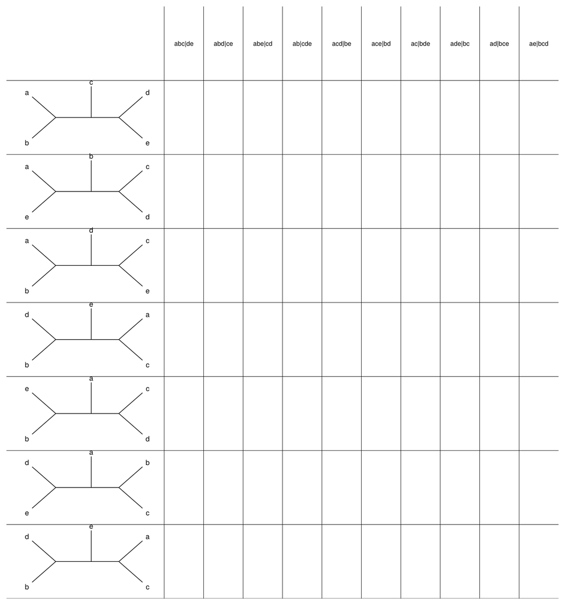

### 3.2 Exercise 2: Clade types and sister groups

- Create a Newick tree file called “lab03-ex2.tre” in your text editor with the content:

  ```
  (((A,(B,C)),((D,E),(F,G))),(H,(I,((J,K),(L,M)))));
  ```

- List all the monophyletic groups on the tree.
- List three paraphyletic groups.
- List three polyphyletic groups.
- List six sister groups.

### 3.3 Exercise 3: Rooting and split tables

- Create a new subdirectory for this exercise, and, in it create a Newick tree file called “lab03-ex1.tre” in your text editor with the content:

  ```
  (((C,(D,E)),(F,G),A),B);
  ```

- Draw the tree by hand
- Write down all the splits in a splits table (i.e. “..**” or “1100” format).
- Re-root the tree. What rootings make the following true? Which cannot be true?
  - A is more closely related to G than it is to C
  - (C,D,E) is sister to (A,B,F,G)
  - (C,D) is sister to (A,B,E,F,G)
  - (C,D,E) is a paraphyletic group
  - (C,D,E) is a monophyletic group
  - (A,B,C) is a monophyletic group

Back to top